# Introdução a Python - Aula 1

**Tipos de operadores**  
1 - Operadores aritméticos  
2 - Variáveis e operadores de atribuição  
3 - Números inteiros e floats  
4 - Booleanos, operadores de comparação e operadores lógicos  
5 - Strings  
6 - Tipo e conversão de tipo  
7 - Métodos de string  
8 - Listas e operadores de assinatura  
9 - Métodos de lista  
10 - Tuplas  
11 - Conjuntos (sets)  
12 - Dicionários e operadores de identidade  
13 - Estruturas de dados compostas

## Tipos de operadores

- Tipos de dados: Inteiros, floats, booleanos, strings, listas, tuplas, conjuntos, dicionários
- Operadores: Aritmética, atribuição, comparação, lógica, assinatura, identidade
- Funções internas, estruturas de dados compostas, conversão de tipo
- Espaço em branco e orientações de estilo

### 1. Operadores aritméticos

- `+` Adição
- `-` Subtração
- `*` Multiplicação
- `/` Divisão
- `%` Mod (o resto da divisão)
- `**` Exponenciação (veja que ^ não faz esta operação, como você pode ter visto em outras linguagens)
- `//` Divide e arredonda para baixo até o inteiro mais próximo

Mais informações sobre operações bit a bit podem ser encontradas [aqui](https://wiki.python.org/moin/BitwiseOperators). A ordem habitual das operações matemáticas é seguida em Python e você pode relembrá-la aqui na página da Wikipédia).

### 2. Variáveis e operadores de atribuição

#### 2.1. Variáveis I

Variáveis são usadas o tempo todo em Python! Aqui abaixo está o exemplo que você viu no vídeo, em que fizemos o seguinte:

```python
mv_population = 74728
```

Aqui, `mv_population` é uma variável que contém o valor `74728`. Isso atribui o item à direita ao nome à esquerda, o que é, na verdade, um pouco diferente da igualdade matemática, já que `74728` não armazena o valor de `mv_population`.

Em qualquer caso, independentemente de qual for o termo do lado esquerdo, ele agora é um nome para o valor que está do lado direito. Uma vez que um valor tiver sido atribuído a um nome de variável, você pode acessá-lo pelo nome da variável.

#### 2.2. Variáveis II

As próximas duas estruturas são equivalentes em termos de atribuição:

```python
x = 3
y = 4
z = 5
```

e

```python
x, y, z = 3, 4, 5
```

No entanto, a maneira acima não é a melhor para atribuir variáveis, na maioria dos casos, porque nossos nomes de variáveis devem ser descritivos dos valores que detêm.

Além de escrever nomes de variáveis que sejam descritivos, há algumas coisas que devemos observar ao nomear variáveis em Python.

1. Utilize apenas letras comuns, números e sublinhados em seus nomes de variáveis. Eles não podem conter espaços e precisam começar com uma letra ou sublinhado.
2. Você não pode usar palavras reservadas ou identificadores internos que tenham finalidades importantes em Python, você vai aprender sobre elas durante todo o curso. Uma lista de palavras reservadas em Python está descrita aqui. Criar nomes que sejam descrições dos valores geralmente ajuda a evitar o uso dessas palavras. Uma pequena tabela de tais palavras também está disponível abaixo.

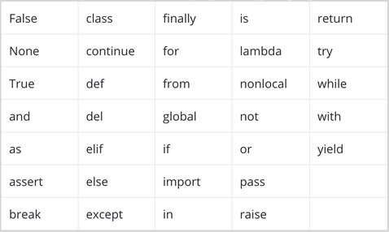

1. A maneira de nomear variáveis em Python é utilizar somente letras minúsculas e separar as palavras com sublinhados

```python
my_height = 58
my_lat = 40
my_long = 105
```

```python
my height = 58
MYLONG = 40
MyLat = 105
```

```
  File "<ipython-input-5-30584174f296>", line 1
    my height = 58
            ^
SyntaxError: invalid syntax
```

Por mais que estas últimas duas estruturas funcionem em Python, elas não são boas maneiras de se nomear variáveis em Python. Esta maneira de nomear variáveis é chamada de “snake case”, porque conectamos as palavras com sublinhados.

#### 2.3. Operadores de atribuição

Abaixo estão os operadores de atribuição do vídeo. Você também pode usar `*=` de uma maneira similar, mas ela é menos comum do que as operações mostradas abaixo. Você pode praticar muito do que nós já cobrimos [aqui](https://www.programiz.com/python-programming/operators).

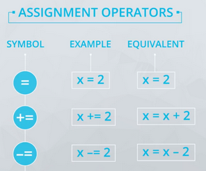

### 3. Números inteiros e floats

Há dois tipos de dados em Python que podem ser utilizados para valores numéricos:

- **int** - para valores inteiros
- **float** - para valores decimais ou de ponto flutuante

Você pode criar um valor que segue um determinado tipo de dados usando a seguinte sintaxe:

```python
x = int(4.7)   # x é inteiro que vale 4
y = float(4)   # y é um float com valor 4.0
print(x)
print(y)
```

```
4
4.0
```

Você pode verificar o tipo, usando a função `type`:

```python
print(type(x))
print(type(y))
```

```
<class 'int'>
<class 'float'>
```

Como flutuação, ou aproximação, para 0,1 é, na verdade, um pouco maior do que 0,1, quando somamos vários dele podemos ver a diferença entre a resposta matematicamente correta e a que o Python cria.

```python
print(.1 + .1 + .1 == .3)
```

```
False
```

Você pode ver mais sobre isso [aqui](https://docs.python.org/3/tutorial/floatingpoint.html).

### 4. Booleanos, operadores de comparação e operadores lógicos

O tipo de dados bool contém os valores `True` ou `False` que, geralmente, são codificados como `1` ou `0`, respectivamente.

Existem seis operadores de comparação que são comuns para obter um valor `bool`:

| Caso de uso de símbolo | Bool | Operação |
| --- | --- | --- |
| 5 < 3 | False | Menor do que |
| 5 > 3 | True | Maior do que |
| 3 <= 3 | True | Menor do que ou igual a |
| 3 >= 5 | False | Maior do que ou igual a |
| 3 == 5 | False | Igual a |
| 3 != 5 | True | Não é igual a |

E existem três operadores lógicos com que você precisa ter familiaridade:

| Uso de lógica | Bool | Operação |
| --- | --- | --- |
| 5 < 3 `and` 5 == 5 | False | `and` - Avalia se ambas as declarações fornecidas são verdadeiras |
| 5 < 3 `or` 5 == 5 | True | `or` - Avalia se pelo menos uma das declarações fornecidas é verdadeira |
| `not` 5 < 3 | True | `not` - Inverte o valor bool |

[Aqui](https://www.irishtimes.com/news/science/how-george-boole-s-zeroes-and-ones-changed-the-world-1.2014673) estão mais informações sobre como George Bool mudou o mundo!

### 5. Strings

Strings, em Python, são sequências de caracteres identificadas pelo tipo de variável `str`. Você pode definir uma string com aspas duplas `"` ou simples `'`. Se a string que você está criando tiver um desses dois valores nela, você precisa ter cuidado para garantir que seu código não resulte em erro.

```python
my_string = 'this is a string!'
my_string2 = "this is also a string!!!"
print(my_string)
print(my_string2)
```

```
this is a string!
this is also a string!!!
```

Você também pode incluir um `\` em sua string para poder incluir aspas:

```python
this_string = 'Simon\'s skateboard is in the garage.'
print(this_string)
```

```
Simon's skateboard is in the garage.
```

Se não usamos isso, podemos obter o seguinte erro:

```python
this_string = 'Simon's skateboard is in the garage.'
```

```
  File "<ipython-input-11-743762e3cecb>", line 1
    this_string = 'Simon's skateboard is in the garage.'
                         ^
SyntaxError: invalid syntax
```

O realce de cor também é uma indicação do erro ocorrido na string, nesse segundo caso. Há uma variedade de outras operações que você também pode utilizar com strings.

```python
first_word = 'Hello'
second_word = 'There'
print(first_word + second_word)

print(first_word + ' ' + second_word)

print(first_word * 5)

print(len(first_word))
```

```
HelloThere
Hello There
HelloHelloHelloHelloHello
5
```

Diferentemente de outros tipos de dados que tenha visto até agora, você também pode indexar strings. Veja que o Python usa o índice 0 para o primeiro elemento.

```python
print(first_word[0])
print(first_word[1])
print(first_word[2])
print(first_word[3])
print(first_word[4])
```

```
H
e
l
l
o
```

#### A função `len()`

`len()` é uma função interna do Python que retorna o comprimento de um objeto, como uma string. O comprimento de uma string é o número de caracteres na string. Sempre será um número inteiro.

Há um exemplo acima, mas segue outro:

```python
print(len("ababa") / len("ab"))
```

```
2.5
```

Você sabe quais são os tipos de dados para len("ababa") e len("ab"). Observe o tipo de dados do quociente resultante aqui.

### 6. Tipo e conversão de tipo

Você viu até agora quatro tipos de dados:

1. **int**
2. **float**
3. **bool**
4. **string**

Você viu rapidamente a função `type()` em um vídeo anterior, e ela pode ser utilizada para verificar o tipo de dado de qualquer variável com a qual estiver trabalhando.

```python
print(type(4))
print(type(3.7))
print(type('this'))
print(type(True))
```

```
<class 'int'>
<class 'float'>
<class 'str'>
<class 'bool'>
```

Você viu que pode alterar os tipos de variáveis para executar diferentes operações. Por exemplo:

```python
"0" + "5"
```

```
'05'
```

fornece uma saída completamente diferente de

```python
0 + 5
```

```
5
```

O que você acha que as estruturas abaixos forneceriam?

```python
"0" + 5
```

```
---------------------------------------------------------------------------
TypeError                                 Traceback (most recent call last)
<ipython-input-18-f3eee68b9620> in <module>
----> 1 "0" + 5

TypeError: can only concatenate str (not "int") to str
```

E o código abaixo?"

```python
0 + "5"
```

```
---------------------------------------------------------------------------
TypeError                                 Traceback (most recent call last)
<ipython-input-19-3dd32333af13> in <module>
----> 1 0 + "5"

TypeError: unsupported operand type(s) for +: 'int' and 'str'
```

Verificar os tipos de variáveis é muito importante para garantir que você está resgatando os resultados que quer obter quando estiver programando.

### 7. Métodos de string

Agora você será introduzido aos métodos, que são como algumas funções que já vimos:

```
len("this")
type(12)
print("Hello world")
```

As três expressões acima são **funções**. Observe que usam parênteses e aceitam um argumento.

As funções `type` e `print` podem receber strings, floats, ints e muitos outros tipos de dados como argumentos e a função `len` também pode aceitar diferentes tipos de dados como argumentos, que você verá mais adiante.

Um **método** em Python é semelhante a uma função, mas atua em uma variável que você já criou. **Métodos** são específicos para o tipo de dado que é armazenado em uma variável particular.

Abaixo está uma imagem que mostra os métodos que são possíveis para qualquer string.

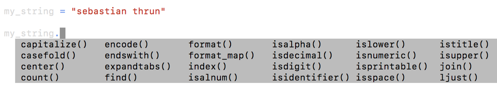

Cada um desses métodos aceita a string em si como seu primeiro argumento. No entanto, eles também podem receber argumentos adicionais. Vamos olhar a saída para alguns exemplos.

```python
print(my_string)
```

```
this is a string!
```

```python
my_string.islower()
```

```
True
```

```python
my_string.count('a')
```

```
1
```

```python
my_string.find('a')
```

```
8
```

Você pode ver que ambos os métodos `count` e `find` podem aceitar outro argumento. No entanto, o método `islower` não aceita um argumento. Se fôssemos armazenar um float, int ou outro tipo de dado em uma variável, os métodos disponíveis seriam completamente diferentes!

Nenhum profissional decora todos os métodos, por isso é tão importante entender como usar a documentação e encontrar respostas. Obter uma forte compreensão dos fundamentos de programação permitirá que você use essas bases para utilizar a documentação para construir muito mais do que alguém que tenta memorizar todas as funções disponíveis no Python.

#### Um método string importante: `format()`

Utilizaremos bastante o método de string `format()` em nosso futuro trabalho no Python, e você descobrirá que esse método é muito valioso durante a programação, especialmente com as declarações print.

Podemos melhor ilustrar como utilizar o `format()` ao observar alguns exemplos:

```python
print("Mohammed has {} balloons".format(27))
```

```
Mohammed has 27 balloons
```

```python
animal = "dog"
action = "bite"
print("Does your {} {}?".format(animal, action))
```

```
Does your dog bite?
```

```python
maria_string = "Maria loves {} and {}"
print(maria_string.format("math","statistics"))
```

```
Maria loves math and statistics
```

Em cada exemplo, observe como o número de chaves `{}` utilizado dentro da string é o mesmo número de substituições que se deseja fazer usando os valores dentro de `format()`.

Você pode aprender mais sobre a sintaxe formal para utilização do método de string `format()` [aqui](https://docs.python.org/3.6/library/string.html#format-string-syntax).

#### Outro importante método de string: `split()`

Um método de string útil ao trabalhar com strings é o método `split()`. Esta função ou método retorna um contêiner de dados, denominado como uma **lista** que contém as palavras da string de entrada. Apresentaremos o conceito de listas no próximo vídeo.

O método split tem dois argumentos adicionais (*sep* e *maxsplit*). O argumento sep significa "separador". Ele pode ser usado para identificar como a string deve ser dividida (por exemplo, caracteres de espaço em branco como espaço, tabulação, enter, nova linha; pontuação específica, por exemplo, vírgula, traços). Se o argumento *sep* não for definido, por padrão, o separador será o espaço em branco.

Conforme o seu nome, o argumento *maxsplit* fornece o número máximo de divisões. O argumento *maxsplit + 1* fornece o número de elementos na nova lista, com a string restante sendo retornada como o último elemento na lista. Você também pode saber mais sobre esses métodos na documentação do Python.

Aqui estão alguns exemplos do método `split()`.

1. Um método básico da função split:

```python
new_str = "The cow jumped over the moon."
new_str.split()
```

```
['The', 'cow', 'jumped', 'over', 'the', 'moon.']
```

1. Agora o separador é o espaço, e o argumento *maxsplit* é definido como 3.

```python
new_str.split(' ', 3)
```

```
['The', 'cow', 'jumped', 'over the moon.']
```

1. Usando '.' ou ponto como um separador.

```python
new_str.split('.')
```

```
['The cow jumped over the moon', '']
```

1. Não utilizando separadores, mas tendo um argumento *maxsplit* de 3.

```python
new_str.split(None, 3)
```

```
['The', 'cow', 'jumped', 'over the moon.']
```

### 8. Listas e operadores de assinatura

#### 8.1. Listas

Você pode criar uma lista com colchetes. As listas podem conter qualquer mistura e combinação de tipos de dados que você viu até agora.

```python
list_of_random_things = [1, 3.4, 'a string', True]
```

Esta é uma lista de 4 elementos. Todos os contentores ordenados (como listas) são indexadas em Python usando um índice inicial de 0. Portanto, para puxar o primeiro valor da lista acima, podemos escrever:

```python
list_of_random_things[0]
```

```
1
```

E se tentarmos obter o último elemento da lista com o código a seguir?

```python
list_of_random_things[len(list_of_random_things)]
```

```
---------------------------------------------------------------------------
IndexError                                Traceback (most recent call last)
<ipython-input-33-ee5743f28c5a> in <module>
----> 1 list_of_random_things[len(list_of_random_things)]

IndexError: list index out of range
```

Não funcionou pois estamos acessando um elemento que não existe (a posição dos elementos na lista começa pelo 0, enquanto a contagem realizada pela função `len()` começa por 1). No entanto, podemos obter o último elemento subtraindo 1 do índice. Então, podemos fazer o seguinte:

```python
list_of_random_things[len(list_of_random_things) - 1]
```

```
True
```

Alternativamente, você pode indexar a partir do final de uma lista usando valores negativos, onde -1 é o último elemento, -2 é o penúltimo elemento e assim por diante.

```python
list_of_random_things[-1]
```

```
True
```

```python
list_of_random_things[-2]
```

```
'a string'
```

#### 8.2. Cortando listas em pedaços menores

Você viu que conseguimos puxar mais de um valor por vez de uma lista se a **cortarmos** em pedaços menores. Ao usar o corte, é importante lembrar que o índice *`inferior` é `inclusivo`* e o índice *`superior` é `exclusivo`*.

Portanto:

```python
list_of_random_things = [1, 3.4, 'a string', True]
list_of_random_things[1:2]
```

```
[3.4]
```

devolve apenas **3,4** de uma lista. Observe que isto ainda é diferente do que indexar apenas um único elemento, pois você obterá uma lista com essa indexação. Os dois pontos dizem-nos para partir do valor à esquerda até, mas não incluindo, o elemento à direita.

Se você sabe que você quer começar do início da lista, pode deixar esse valor em branco.

```python
list_of_random_things[:2]
```

```
[1, 3.4]
```

ou, para puxar todos os elementos do final da lista, podemos deixar em branco o elemento final.

```python
list_of_random_things[1:]
```

```
[3.4, 'a string', True]
```

Esse tipo de indexação funciona exatamente da mesma maneira com strings, onde o valor devolvido será uma string.

#### 8.4. Você está `in` ou `not in`?

Você viu que nós também podemos usar `in` e `not in` para retornar um **bool** que afirma se um elemento existe ou não dentro de nossa lista ou se uma string é uma substring de outra.

```python
'this' in 'this is a string'
```

```
True
```

```python
'in' in 'this is a string'
```

```
True
```

```python
'isa' in 'this is a string'
```

```
False
```

```python
 5 not in [1, 2, 3, 4, 6]
```

```
True
```

```python
5 in [1, 2, 3, 4, 6]
```

```
False
```

#### 8.5. Mutabilidade e ordem

**Mutabilidade** indica se podemos ou não alterar um objeto depois que ele foi criado. Se um objeto (como uma lista ou string) pode ser alterado (tal qual uma lista pode), então dizemos que ele é **mutável**. No entanto, se um objeto não pode ser alterado com a criação de um objeto completamente novo (como as strings), então o objeto é considerado **imutável**.

```python
my_lst = [1, 2, 3, 4, 5]
my_lst[0] = 'one'
print(my_lst)
```

```
['one', 2, 3, 4, 5]
```

Como mostrado acima, você é capaz de substituir 1 por 'one' na lista acima. Isso ocorre porque listas são **mutáveis**.

No entanto, o seguinte não funciona:

```python
greeting = "Hello there"
greeting[0] = 'M'
```

```
---------------------------------------------------------------------------
TypeError                                 Traceback (most recent call last)
<ipython-input-46-023028cc6e1a> in <module>
      1 greeting = "Hello there"
----> 2 greeting[0] = 'M'

TypeError: 'str' object does not support item assignment
```

Isso ocorre porque strings são **imutáveis** Isso significa que, para alterar uma string, você precisará criar uma string completamente nova.

Há duas coisas a se ter em mente para cada um dos tipos de dados que você está usando:

1. Eles são **mutáveis**?
2. Eles são **ordenados**? Tanto strings quanto listas são ordenadas. No entanto, nas próximas seções, você verá alguns tipos de dados que não serão ordenados. Para cada uma das próximas estruturas de dados que você verá, é útil entender como você deve indexar, se são mutáveis e se são ordenados. Saber isso sobre a estrutura de dados é realmente útil!

Além disso, você verá como cada um deles tem métodos diferentes, então, utilizar uma estrutura de dados ou outra é largamente dependente dessas propriedades, e o que você pode facilmente fazer com elas!

### 9. Métodos de lista

#### Funções úteis para listas I

1. `len()` devolve quantos elementos existem em uma lista.
2. `max()` devolve o maior elemento da lista. A maneira como é determinado o maior elemento de uma lista depende de quais tipos de objetos estão presentes na lista. O elemento máximo em uma lista de números é o maior número. O elemento máximo de uma lista de strings é o elemento que ocorreria por último caso a lista estivesse em ordem alfabética. Isso funciona porque a função máximo é definida em termos do operador de comparação ‘maior do que’. A função máximo é indefinida para listas que contêm elementos de tipos diferentes, incomparáveis.
3. `min()` devolve o menor elemento em uma lista. Mínimo é o oposto de máximo e retorna o menor elemento de uma lista.
4. `sorted()` devolve uma cópia de uma lista, ordenada do menor para o maior, deixando a lista inalterada.

#### Funções úteis para listas II

**Método `join()`**  
`join()` é um método de strings que recebe uma lista de strings como argumento e devolve uma string formada pelos elementos da lista unidos por um separador de strings. No primeiro exemplo, usamos a string "\n" como separador para que haja uma nova linha entre cada elemento. Podemos também utilizar outras strings como separadores com `join()`, como hífen.

```python
new_str = "\n".join(["fore", "aft", "starboard", "port"])
print(new_str)
```

```
fore
aft
starboard
port
```

```python
new_str = "-".join(["fore", "aft", "starboard", "port"])
print(new_str)
```

```
fore-aft-starboard-port
```

Neste exemplo, usamos a string "\n" como separador para que haja uma nova linha entre cada elemento. Podemos também utilizar outras strings como separadores com .join. Aqui, usamos um hífen.

**Método `append()`**  
Este método é útil adicionar um elemento ao final de uma lista.

```python
letters = ['a', 'b', 'c', 'd']
letters.append('z')
print(letters)
```

```
['a', 'b', 'c', 'd', 'z']
```

### 10. Tuplas

Uma tupla é um outro contentor útil. É um tipo de dados para sequências ordenadas imutáveis de elementos. Elas são frequentemente usadas para armazenar pedaços relacionados de informação. Considere este exemplo envolvendo latitude e longitude:

```python
location = (13.4125, 103.866667)
print("Latitude:", location[0])
```

```
Latitude: 13.4125
```

```python
print("Longitude:", location[1])
```

```
Longitude: 103.866667
```

Tuplas são semelhantes a listas, pois também armazenam uma coleção ordenada de objetos que podem ser acessados por meio de seus índices. Ao contrário das listas, no entanto, as tuplas são imutáveis - não é possível adicionar e remover itens de tuplas ou classificá-las no lugar.

As tuplas também podem ser usadas para fazer a atribuição de diversas variáveis de uma forma compacta.

```python
dimensions = 52, 40, 100
length, width, height = dimensions
print("The dimensions are {} x {} x {}".format(length, width, height))
```

```
The dimensions are 52 x 40 x 100
```

Os parênteses são opcionais ao definir tuplas, e programadores frequentemente os omitem caso não ajudem a esclarecer o código.

Na segunda linha, três variáveis são atribuídas a partir do conteúdo das dimensões tupla. Esse processo é chamado **desempacotamento de tupla**. Você pode usar o desempacotamento de tupla para atribuir as informações de uma tupla a múltiplas variáveis sem precisar acessá-las uma a uma e executar várias instruções de atribuição.

Se não precisássemos usar `dimensions` diretamente, poderíamos encurtar essas duas linhas de código para uma única linha que atribui três variáveis de uma só vez!

```python
length, width, height = 52, 40, 100
print("The dimensions are {} x {} x {}".format(length, width, height))
```

```
The dimensions are 52 x 40 x 100
```

### 11. Conjuntos (sets)

Um **conjunto** é um tipo de dados para coleções mutáveis não ordenadas de elementos únicos. Uma aplicação de um conjunto é remover rapidamente duplicatas de uma lista.

```python
numbers = [1, 2, 6, 3, 1, 1, 6]
unique_nums = set(numbers)
print(unique_nums)
```

```
{1, 2, 3, 6}
```

Conjuntos aceitam o operador `in` da mesma forma que as listas. Você pode adicionar elementos aos conjuntos usando o método `add`, e removê-los usando o método `pop`, tal como nas listas. Porém, quando você utiliza pop para remover um elemento de um conjunto, um elemento aleatório é removido. Lembre-se de que *conjuntos, ao contrário das listas, não são ordenados*, então, não há um “último elemento”.

```python
fruit = {"apple", "banana", "orange", "grapefruit"}  # define a set
print("watermelon" in fruit)  # check for element
fruit.add("watermelon")  # add an element
print(fruit)
print(fruit.pop())  # remove a random element
print(fruit)
```

```
False
{'grapefruit', 'banana', 'apple', 'orange', 'watermelon'}
grapefruit
{'banana', 'apple', 'orange', 'watermelon'}
```

Outras operações que você pode executar com conjuntos incluem aquelas de conjuntos matemáticos. Métodos como união, interseção e diferença são fáceis de realizar com conjuntos e são muito mais rápidos do que esses operadores com outros contentores.

### 12. Dicionários e operadores de identidade

#### Dicionários

Um **dicionário** é um tipo de dado mutável que armazena mapeamentos de chaves exclusivas para os valores. Aqui está um dicionário que armazena elementos e seus números atômicos.

```python
elements = {"hydrogen": 1, "helium": 2, "carbon": 6}
print(elements)
```

```
{'hydrogen': 1, 'helium': 2, 'carbon': 6}
```

Os dicionários podem ter chaves de qualquer tipo imutável, como inteiros ou tuplas, não apenas strings. Não é necessário sequer que todas as chaves sejam do mesmo tipo! Podemos procurar por valores ou inserir novos valores no dicionário usando colchetes que contenham a chave.

```python
print(elements["helium"])  # imprime o valor mapeado a "helium"
elements["lithium"] = 3  # insere "lithium" com um valor de 3 no dicionário
print(elements)
```

```
2
{'hydrogen': 1, 'helium': 2, 'carbon': 6, 'lithium': 3}
```

Podemos verificar se um valor está em um dicionário da mesma forma que verificamos se um valor está em uma lista ou conjunto com a palavra-chave `in`. Os dicionários têm um método relacionado que também é útil, o `get`. Esse método procura valores em um dicionário, mas, ao contrário de colchetes, devolve `none` (ou um valor padrão de sua escolha) se a chave não for encontrada.

```python
print("carbon" in elements)
print(elements.get("dilithium"))
```

```
True
None
```

Carbono está no dicionário, então **True** é exibido. Dilithium não está em nosso dicionário, então `none` é devolvido por `get` e depois exibido. Se você espera que as pesquisas às vezes falhem, get pode ser uma ferramenta melhor do que as pesquisas normais com colchetes, porque erros podem quebrar o seu programa. Os dicionários não podem ser indexados como vetores:

```python
elements[0]
```

```
---------------------------------------------------------------------------
KeyError                                  Traceback (most recent call last)
<ipython-input-59-1becf99be085> in <module>
----> 1 elements[0]

KeyError: 0
```

#### Operadores de identidade

| Keyword | Operator |
| --- | --- |
| `is` | Avalia se ambos os lados tem a mesma identidade |
| `is not` | Avalia se ambos os lados tem identidade diferente |

Você pode verificar se uma chave devolveu `none` com o operador `is`. Você pode verificar o oposto utilizando `is not`.

```python
n = elements.get("dilithium")
print(n is None)
print(n is not None)
```

```
True
False
```

### 13. Estruturas de dados compostas

Podemos incluir contentores em outros contentores para criar estruturas de dados compostas. Por exemplo, este dicionário mapeia chaves para valores que são também dicionários!

```python
elements = {"hydrogen": {"number": 1,
                         "weight": 1.00794,
                         "symbol": "H"},
              "helium": {"number": 2,
                         "weight": 4.002602,
                         "symbol": "He"}}
```

Podemos acessar elementos no dicionário aninhados assim.

```python
helium = elements["helium"]  # pega o dicionário de helium
hydrogen_weight = elements["hydrogen"]["weight"]  # pega o weight (peso) de hydrogen
```

Você também pode adicionar uma nova chave ao dicionário de elementos.

```python
oxygen = {"number":8,"weight":15.999,"symbol":"O"}  # cria um novo dicionário oxygen
elements["oxygen"] = oxygen  # coloca 'oxygen' como chave para o dicionário de elementos
print('elements = ', elements)
```

```
elements =  {'hydrogen': {'number': 1, 'weight': 1.00794, 'symbol': 'H'}, 'helium': {'number': 2, 'weight': 4.002602, 'symbol': 'He'}, 'oxygen': {'number': 8, 'weight': 15.999, 'symbol': 'O'}}
```

O resultado é:

```python
elements =  {"hydrogen": {"number": 1,
                          "weight": 1.00794,
                          "symbol": 'H'},
               "helium": {"number": 2,
                          "weight": 4.002602,
                          "symbol": "He"},
               "oxygen": {"number": 8,
                          "weight": 15.999,
                          "symbol": "O"}}
```